# `DA3-HW1`

2000692

# Abstract

Suppose that in Los Angeles, you have a company operating small and mid-sized apartments holding 2-6 people, and now you have a several sets of new apartment to promote on the market. How will you properly price them so that each apartment can be rented out at fair returns?

# Introduction

This passage based on data from **InsideAirBnb**, Los Angeles, on 02 January, 2021, helps predict the rental price of apartments which can accommodate 2-6 people, using machine learning tools including OLS, LASSO algorithm and Random Forest. Our research result will give reference for airbnb hosts and real estate mediators on house renting business in Los Angles.

# Data Preparation

We concentrate on Airbnb listing prices of Los Angeles, on 02 January, 2021. We retrieved the data from **InsideAirBnb**, which include indicators such as listing price, room type, amenities available, minimum nights required and so forth. The original data set has 32175 observations, and after cleaning, we have 9386 observations and more than 120 variables to present the property of each listing. The data cleaning process is as follows:

- Filtering listing accommodating capacity, only size between 2 and 6 are chosen.
- simplify property and room to 3-4 types, and make them categorical variables.
- change continuous columns (such as response rate and price) as numerical variables.
- split column “amenities” into more columns, so that each column represent one facility (e.g. coffee machine) of the original “amenities” column.
- make all facility columns as dummy variables, combined with categorical and continuous variables, to form a clean data set for subsequent analysis.
- check missing values of all columns, delete observations with missing values in price and replace other columns with the mean value.

These data were scraped from the official Airbnb website by InsideAirBnb professionals, and thus have quite high quality, so measurement error can be neglected. And also, we are confident that the data represents the current status of apartment renting market in Los Angles.

# EDA and Feature Engineering

## Quick look at price

In this part, we check the summary statistics of defendant variable and some explanatory variables using domain knowledge, and decide which variable to add in our trial models. Also, we draw box plots of certain variables, to find possible interaction betweeen them.

The rental price here is US dollars, and we start with its summary statistics and histogram:

Summary Statistics of Apartment Price

| Varible | n_observation | Mean | Median | Min | Max | Std. | Skew |
| --- | --- | --- | --- | --- | --- | --- | --- |
| price | 9565 | 130 | 110 | 15 | 975 | 82.7 | 3.44 |

From the statistics table and Figure1., we can see that apartment price is hugely skewed with a long right tail: there are several outliers exceeding 900 dollars, which fall outside the 95% percentile of the data. Considering the proportion of these extreme values, we decide to drop values larger than 375 or smaller than 20 dollars (this [20, 375] range includes 95% of the data), and take natural logs of price.

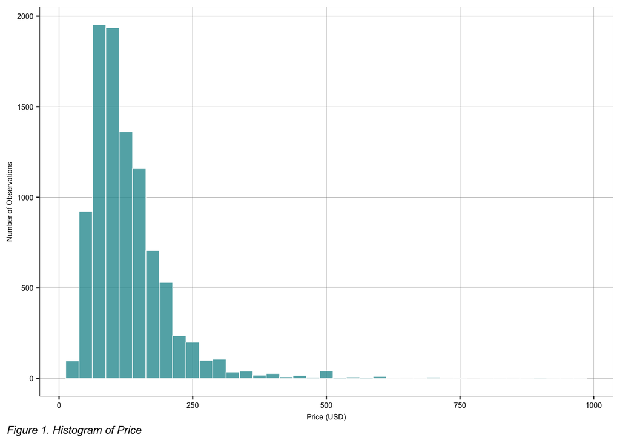

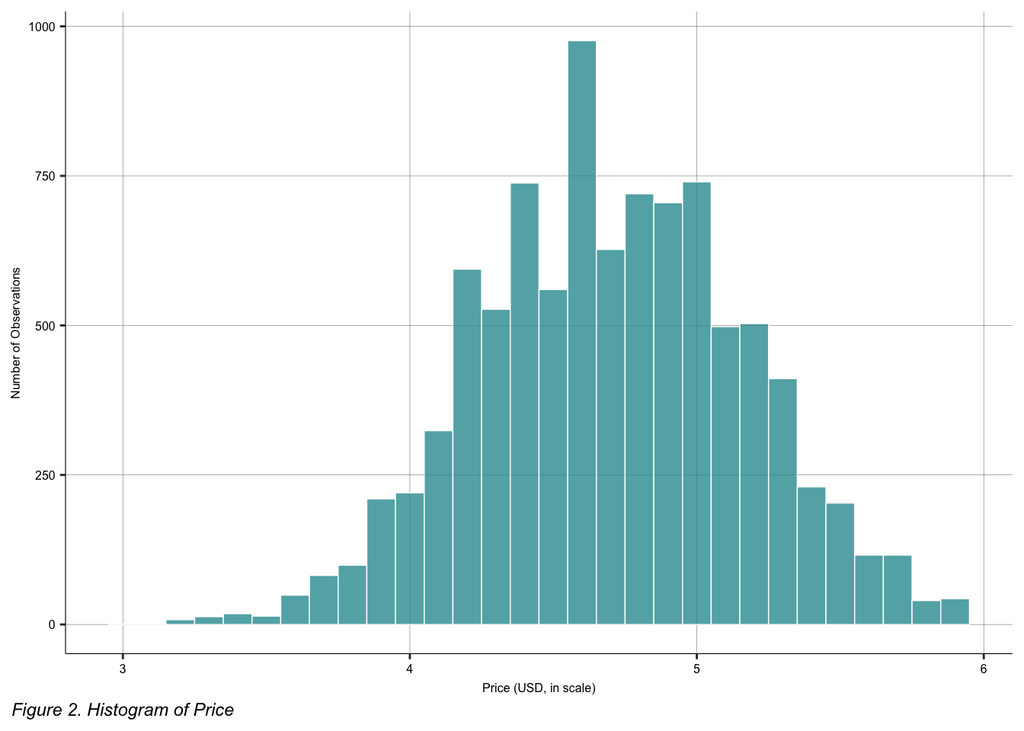

Check Figure 2., we find that ln_price is nearly normal distributed; we will keep this log variable for further analysis.

## Explanatory Variables

We pay special attention to some key explanatory variables (i.e. accommodate capacity, number of beds, number of reviews and so forth) and check their distribution. Similar to how we deal with price variable, we remove extreme values and take natural logarithm if these variables are skewed with a long right tail. We also take square form of accommodate and its logarithm to approximate a subsequent polynomial pattern between price and accommodate capacity variable.

Furthermore, we name one more categorical variable: minimum nights allowed. We check its distribution and split the variable into three slots:[0, 4], [4, 135] and [135, max], which respectively represent 50%, 95% and the rest of the variable distribution.

In the end, we check the data again and do some housekeeping work by changing all infinite values in all columns as N/A values, which are generated from taking logs.

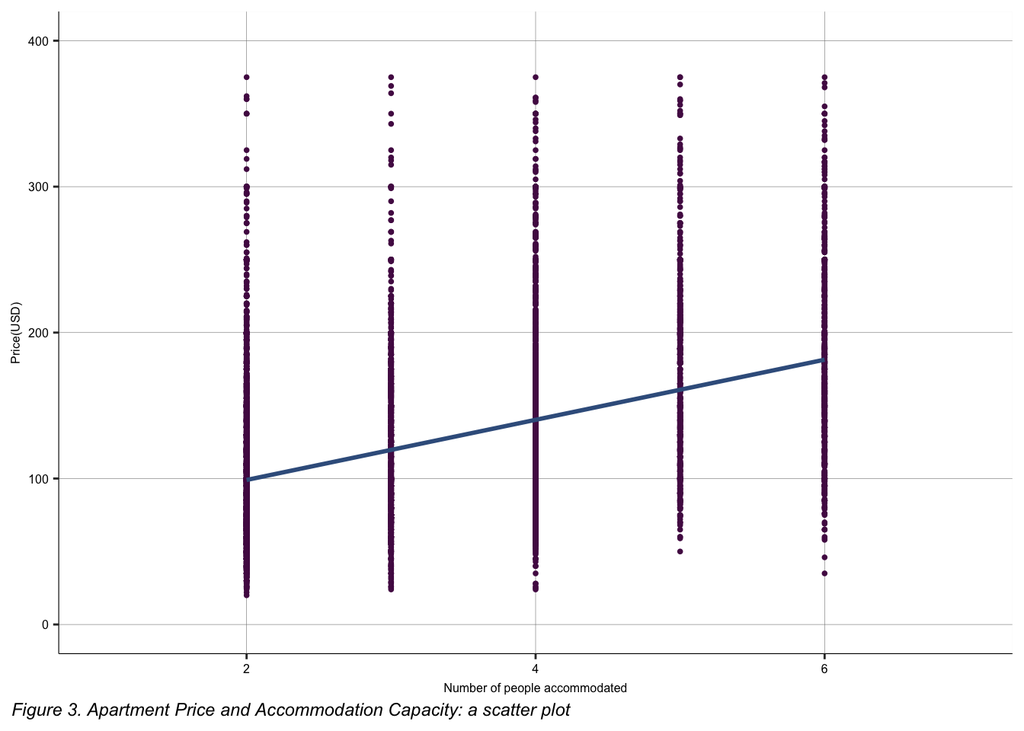

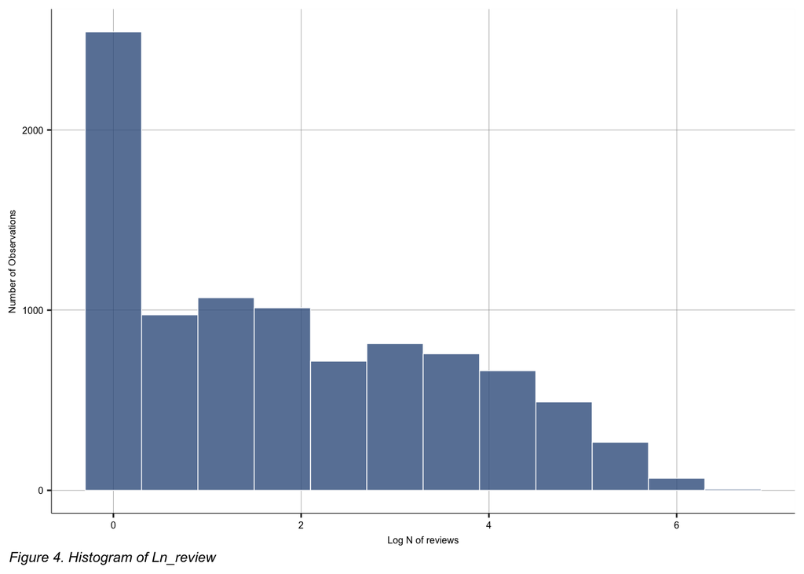

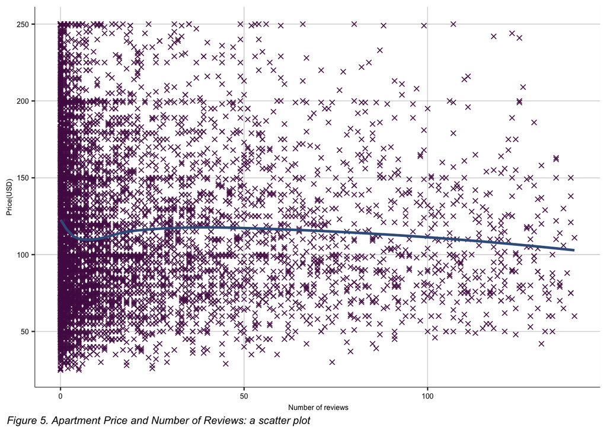

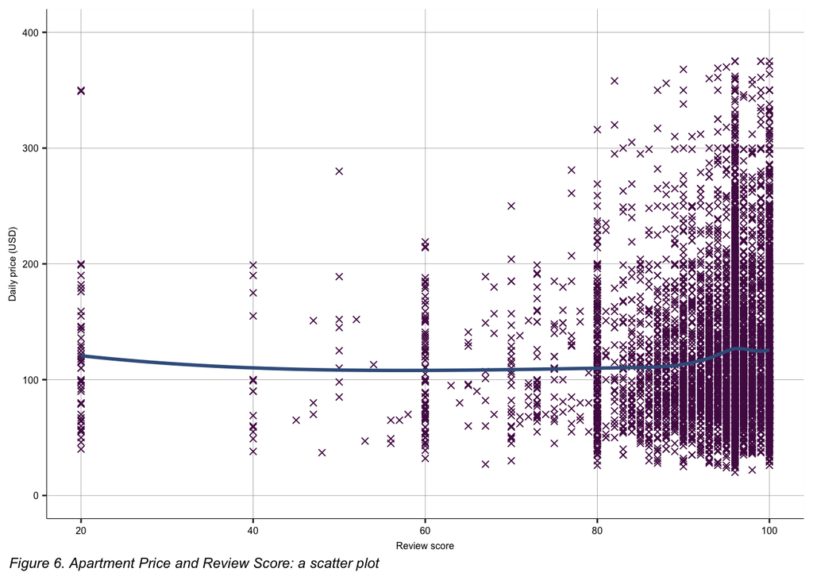

# Model Building, Prediction and Model Selection

## Variable Categorization

Now we have 122 variables, and it seems physical demanding and confusing to add them one by one to our model. So, we categorize them into four groups:

- Basic Variables: include basic key variables such as accommodate capacity, number of beds, property type and room type.
- Factorized variables: number_of_reviews, review scores and flag of review scores.
- Higher-order variables: square form of accommodate capacity, square and cubic form of days since last scraped the information.
- Dummy variables: facilities included in amenities and original binary variables such as “if hose is super host”.

## Interaction

Also, we wonder whether there are certain interactions among variables, and thus we choose several dummy variables to interact with our factorised variables such as room types. As shown in the chart, the average price moves up and down when room type changes and when dummy variables take different values, which is also our criterion to choose certain variables for interaction: whether these variables significantly changes apartment price. We will add these interaction part in subsequent models.

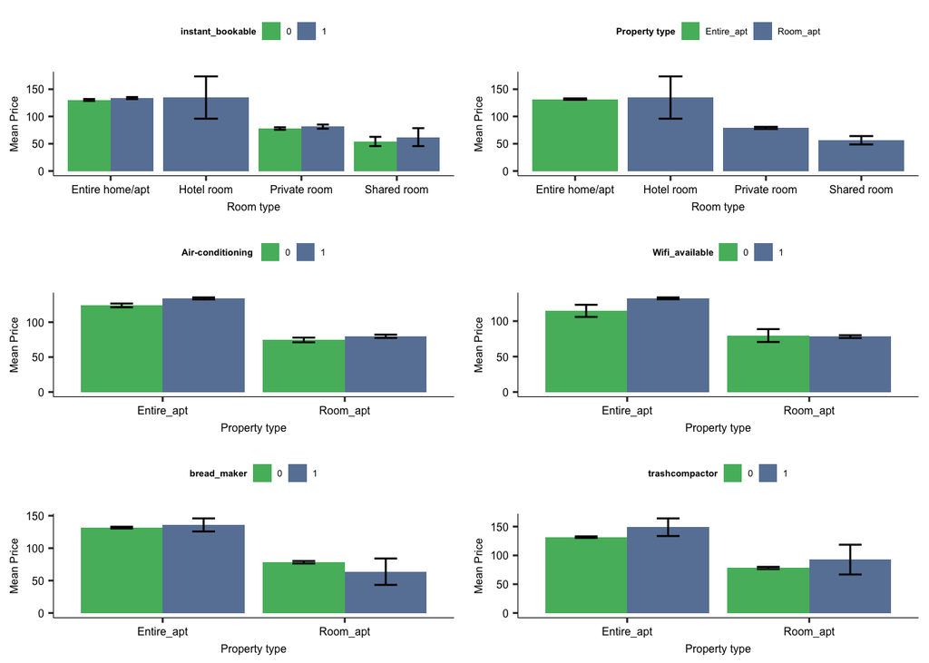

## Model and Sub-models

After all previous steps, we now have 9386 observations, in which 20% will be randomly chosen as holdout set and the rest with 7509 observations will used for 5-fold cross validation (incl. training and test sets). We opt for three models: OLS regression model, LASSO and Random Forest. We will start one by one and assess their prediction performance.

### OLS

For OLS linear regression we have specified 8 models for predicting price. Note that all models take Log price as target variable, and as we move ahead, each model will become more sophisticated as more explanatory variables and interactions join. The predictor variables included in the 8 regression models are shown in table 2.

Table 2: Versions of the Airbnb apartment price prediction models

| Model | Predictor Variables | N Var |
| --- | --- | --- |
| M1 | ~ n_accommodates | 1 |
| M2 | ~ M1 + n_beds, f_property_type, f_room_type, n_days_since, flag_days_since | 6 |
| M3 | ~ M2 + f_number_of_reviews, n_review_scores_rating, flag_review_scores_rating | 9 |
| M4 | ~ M3 + n_accommodates2, n_days_since2, n_days_since3 | 12 |
| M5 | ~ M4 + f_room_type×f_property_type, f_room_type×d_instant_bookable | 15 |
| M6 | ~ M5 + d_wifi_agg×f_property_type, d_bread_maker×f_property_type, d_trashcompactor×f_property_type | 21 |
| M7 | ~ M6 + All amenities | 105 |
| M8 | ~ M7 + interaction of amenities and property and room types | 209 |

First, we estimate all regressions using all observations in the work set and calculate R-squared and BIC. Then, we estimated the models again using 5-fold cross-validation: for each fold, we estimated the regression using the training set, and used it for prediction not only in the training set but also in the corresponding test set. Finally, we collect RMSE for each model as means to assess each modal performance.

Table 3 shows the number of variables, R-squared, BIC, and cross-validated training set and test set RMSE for the eight regressions.

Table 3: Comparing Model Fit Measures

Model

N predictors

R-squared

BIC

Training RMSE

Test RMSE

1

0.214

8078

0.414

0.414

6

0.315

7091

0.386

0.387

9

0.332

6933

0.381

0.382

12

0.346

4746

0.369

0.370

15

0.347

4768

0.369

0.371

21

0.349

4802

0.368

0.371

105

0.450

4595

0.338

0.347

209

0.469

5297

0.331

0.517

R-squared in the work set keeps increasing as more and more predictor variables are added and the most complex model explains 47% of the variation in prices. However, the BIC shows an first downward but then upward trend throughout models. According to the BIC, the best model is regression M7, while the most complex model M8 have a high risk of overly fitting the data.

RMSE in the training sets keeps improving with model complexity. The test set RMSE improves too, until M7, but it is substantially worse for the more complex M8. Thus, M7 produces the lowest test RMSE, with a value of 0.347.

In a word, both BIC and cross-validation produce unanimous results, which picks model M7.

### LASSO

The LASSO algorithm is completely automated in R, and all we have to do is specify a regression with a large set of starting predictor variables, and push the run button. Thus, the most important task is specifying the set of candidate x variables. Here we start with the variables in our Model 8, which includes all of the variables.

#### Prediction Result

We ran the LASSO algorithm with 5-fold cross-validation for selecting the optimal value for λ. In the end, LASSO returns with an estimated regression that has fewer coefficients: it chooses zero for some of the coefficients, which practically means dropping the corresponding variables from the regression. For the variables that it retains, LASSO gives estimated coefficients.

| variable | coefficient | RMSE |
| --- | --- | --- |
| (Intercept) | 4.68 | 0.137 |
| price | 0.38 | 0.137 |
| n_accommodates | 0.00 | 0.137 |
| n_beds | 0.00 | 0.137 |
| f_property_typeRoom_apt | -0.02 | 0.137 |
| f_room_typeHotel room | 0.00 | 0.137 |

Up till now, we prefer model M7 over LASSO, because it may be easier to explain which variables are included.

#### Diagnsotics

After estimating M7 model on all observations in the work sample, we calculated its RMSE in the holdout sample. The RMSE for M7 is 0.337. The holdout set RMSE is slightly smaller than the cross-validated RMSE, as the sample size that we use for the prediction is larger than for cross-validation.

### Random Forest

A random forest needs little tuning, just three parameters:

- the number of bootstrap samples,
- the number of variables considered for each split,
- and the minimum number of observations in the terminal nodes of each tree as a stopping rule.

For the number of bootstap draws, we went with the default option of 500. For the number of variables, we tried 8.10 and 12. For the minimum number of observations in the terminal nodes we choose 5, 10, and 15.

Table 5. shows the cross-validated test set RMSE values for the nine combinations of these tuning parameters. The lowest RMSE values of 44.2 is for 5 observations in the terminal nodes and 12 variables to consider at each split.

Random Forest RMSE by tuning parameters

| nodes | vars 8 | vars 10 | vars 12 |
| --- | --- | --- | --- |
| 5 | 45.6 | 44.7 | 44.2 |
| 10 | 45.7 | 44.8 | 44.3 |
| 15 | 45.7 | 44.9 | 44.4 |

#### Diagnostics: Variable Importance Plot

For random forest, it’s hard to understand what patterns of association between y and x. However, with the help of variable importance plot, we can capture which x variables matter most for the prediction.

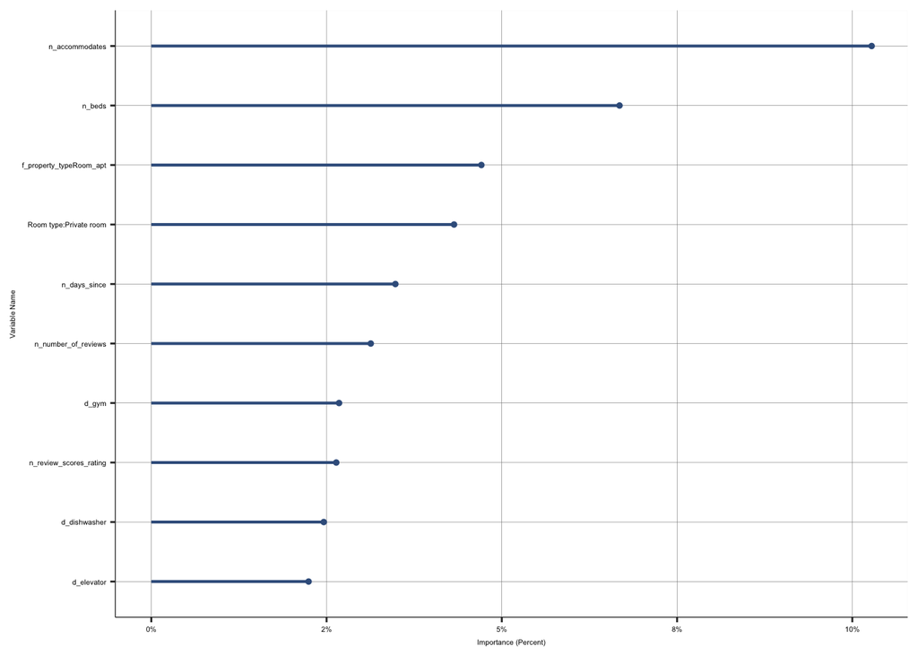

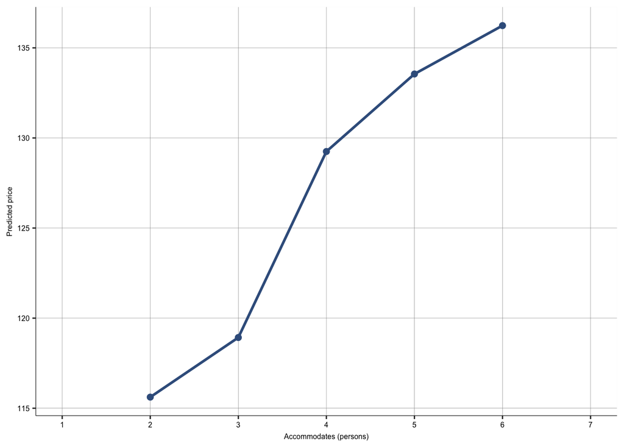

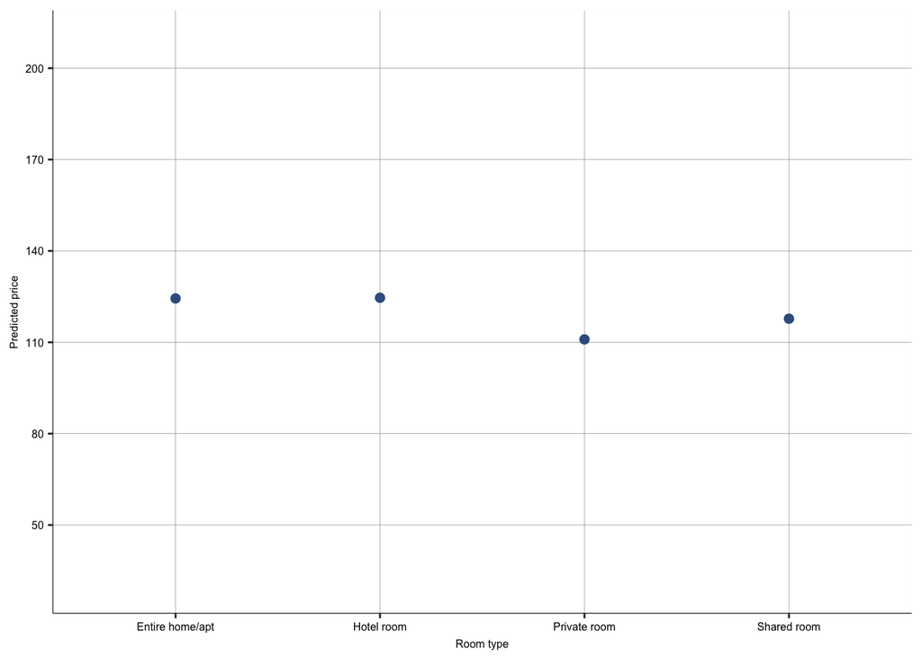

# Summary

The goal of this passage is to predict apartment(2-6 people) price in Los Angles. The data are collected from Inside Airbnb LA region. We clean and transform data, and design OLS, LASSO and Random Forest Models to assist in our decision. BIC and RMSE are the criteria to assess each model. As a result, we esteem Model 7, the one with all variables and interactions among bread maker, trash compacter and wifi availability as the best one to predict price.